# Data Science Project: E-commerce

Justin Gusho

justin.gusho@student.uni-halle.de

#### February 2024

```r
#path
#"C:/Users/justi/OneDrive/Desktop"

# Upload dataset

my_data <- fread(file = "E-commerce.csv")
my_data
```

| ID | Warehouse_block | Mode_of_Shipment | Customer_care_calls | Customer_rating | Cost_of_the_Product | Prior_purchases | Product_importance | Gender | Discount_offered | Weight_in_gms | Reached.on.Time_Y.N |
| --- | --- | --- | --- | --- | --- | --- | --- | --- | --- | --- | --- |
| 1 | D | Flight | 4 | 2 | 177 | 3 | low | F | 44 | 1233 | 1 |
| 2 | F | Flight | 4 | 5 | 216 | 2 | low | M | 59 | 3088 | 1 |
| 3 | A | Flight | 2 | 2 | 183 | 4 | low | M | 48 | 3374 | 1 |
| 4 | B | Flight | 3 | 3 | 176 | 4 | medium | M | 10 | 1177 | 1 |
| 5 | C | Flight | 2 | 2 | 184 | 3 | medium | F | 46 | 2484 | 1 |
| 6 | F | Flight | 3 | 1 | 162 | 3 | medium | F | 12 | 1417 | 1 |
| 7 | D | Flight | 3 | 4 | 250 | 3 | low | F | 3 | 2371 | 1 |
| 8 | F | Flight | 4 | 1 | 233 | 2 | low | F | 48 | 2804 | 1 |
| 9 | A | Flight | 3 | 4 | 150 | 3 | low | F | 11 | 1861 | 1 |
| 10 | B | Flight | 3 | 2 | 164 | 3 | medium | F | 29 | 1187 | 1 |

[output cut: 990 more lines]

# Dictionary

```r
##Variable            ##Description

#ID                    #ID Number of Customers

#Warehouse Block       #Company`s Warehouses such as A,B,C,D,F

#Mode of shipment      #The way the company ships the products (Ship, Flight, Road)

#Customer care calls   #The number of calls made from customers for inquiry of the shipment

#Customer ratings      #The rating of the customers for the service of the company based on prior purchases 1(the lowest) to 5(the highest)

#Cost of the product   #Cost of the product in US dollars

#Prior purchases       #The number of prior purchases from each customer

#Product importance    #The importance of the purchased product specified by company (such as low, medium, high)

#Gender                #Male or female

#Discount offered      #Discount offered on that specific purchased product

#Weight in gms         #The weight of the product in grams

#Reached on time       #The target variable, 1 indicates that the product has NOT reached on time and 0 otherwise
```

The variable `ID` will not be that much important for my project so I will drop this column out. I suppose that all warehouses have similar on-time delivery rates so `Warehouse Block` might not contribute much to the predictive power of my model. `Mode of shipment` could be a crucial variable as different shipping methods may have varying delivery times resulting in more on - time deliveries. I converted it into a factor variable to be able to make calculations later on. The `Customer Care Calls` could indicate customer dissatisfaction or issues with the delivery process. Higher number might correlate with delays.

Higher product costs might be associated with extra or higher premium services, potentially influencing on-time delivery, so the `Cost of the product` variable might help to explore this relationship. `Prior purchases` tells how many times that specific customer has made a purchase. Customers with a history of prior purchases might have different experiences with the delivery process. It could be a relevant predictor for the models which will be built later on.

The importance of the product purchased by the customer, which is shown by the `Product importance`, column might influence the level of care and attention given during shipping. Initially, the variable was identified as a character type. I converted the `Product Importance` variable to an ordered factor to represent the ordinal nature of the categories (“low,” “medium,” “high”).

I think that the sex of the customers might not necessarily influence on-time delivery. The `Gender` variable will not be much important. The impact of discounts on delivery time might be a crucial factor for the prediction. This is showed by `Discount offered` column.

When we talk about the weight of the purchased products it is important to know that heavier products might require more time for processing and shipping, potentially impacting the delivery time. This will be explored in the `Weight in gms` column. `Reached on time` is the target binary variable which indicates if the product reached on time or not

# Data manipulation

Firstly, I checked for missing values and duplicates. Fortunately, no missing values were found and there were no duplicate rows. Then I dropped out 2 irrelevant columns in order to make my work easier and more efficient while doing calculations and building the models.

By looking at the structure of the data I distinguished that 3 variables needed to be converted into factors in order to be able to make calculations.

To gain a deeper understanding of the dataset, I employed the `summary` function. I observed that the most common mode of shipment was `Ship` with a significant lead over `Flight` and `Road`. This information is crucial for understanding the distribution of shipping methods within dataset. The summary statistics showed that the highest product cost was 310 $ , while the lowest cost was recorded at 96 $ . This broad range in product costs is noteworthy and will be further explored in the analyses. It revealed interesting insights into the distribution of `Product_importance`. While the highest level of product importance `high` was assigned to 948 products, the other two levels `low` and `medium` had a higher frequency

```r
#rename variable
setnames(my_data,"Reached.on.Time_Y.N","Reached_on_Time")

#missing values
na.omit(my_data)
```

| ID | Warehouse_block | Mode_of_Shipment | Customer_care_calls | Customer_rating | Cost_of_the_Product | Prior_purchases | Product_importance | Gender | Discount_offered | Weight_in_gms | Reached_on_Time |
| --- | --- | --- | --- | --- | --- | --- | --- | --- | --- | --- | --- |
| 1 | D | Flight | 4 | 2 | 177 | 3 | low | F | 44 | 1233 | 1 |
| 2 | F | Flight | 4 | 5 | 216 | 2 | low | M | 59 | 3088 | 1 |
| 3 | A | Flight | 2 | 2 | 183 | 4 | low | M | 48 | 3374 | 1 |
| 4 | B | Flight | 3 | 3 | 176 | 4 | medium | M | 10 | 1177 | 1 |
| 5 | C | Flight | 2 | 2 | 184 | 3 | medium | F | 46 | 2484 | 1 |
| 6 | F | Flight | 3 | 1 | 162 | 3 | medium | F | 12 | 1417 | 1 |
| 7 | D | Flight | 3 | 4 | 250 | 3 | low | F | 3 | 2371 | 1 |
| 8 | F | Flight | 4 | 1 | 233 | 2 | low | F | 48 | 2804 | 1 |
| 9 | A | Flight | 3 | 4 | 150 | 3 | low | F | 11 | 1861 | 1 |
| 10 | B | Flight | 3 | 2 | 164 | 3 | medium | F | 29 | 1187 | 1 |

[output cut: 990 more lines]

```r
#checking for duplicates
my_data[,.N]-uniqueN(my_data)
```

```
[1] 0
```

```r
#deleting irrelevant columns
my_data[, c("ID", "Warehouse_block" ) := NULL]

str(my_data)
```

```
Classes ‘data.table’ and 'data.frame':  10999 obs. of  10 variables:
 $ Mode_of_Shipment   : chr  "Flight" "Flight" "Flight" "Flight" ...
 $ Customer_care_calls: int  4 4 2 3 2 3 3 4 3 3 ...
 $ Customer_rating    : int  2 5 2 3 2 1 4 1 4 2 ...
 $ Cost_of_the_Product: int  177 216 183 176 184 162 250 233 150 164 ...
 $ Prior_purchases    : int  3 2 4 4 3 3 3 2 3 3 ...
 $ Product_importance : chr  "low" "low" "low" "medium" ...
 $ Gender             : chr  "F" "M" "M" "M" ...
 $ Discount_offered   : int  44 59 48 10 46 12 3 48 11 29 ...
 $ Weight_in_gms      : int  1233 3088 3374 1177 2484 1417 2371 2804 1861 1187 ...
 $ Reached_on_Time    : int  1 1 1 1 1 1 1 1 1 1 ...
 - attr(*, ".internal.selfref")=<externalptr>
```

```r
#converting 3 variables into factors
my_data$Product_importance <- factor(my_data$Product_importance, ordered = TRUE, levels = c("low", "medium", "high"))

my_data[, Mode_of_Shipment := as.factor(Mode_of_Shipment)]

my_data[, Gender := as.factor(Gender)]

#structure of the data
str(my_data)
```

```
Classes ‘data.table’ and 'data.frame':  10999 obs. of  10 variables:
 $ Mode_of_Shipment   : Factor w/ 3 levels "Flight","Road",..: 1 1 1 1 1 1 1 1 1 1 ...
 $ Customer_care_calls: int  4 4 2 3 2 3 3 4 3 3 ...
 $ Customer_rating    : int  2 5 2 3 2 1 4 1 4 2 ...
 $ Cost_of_the_Product: int  177 216 183 176 184 162 250 233 150 164 ...
 $ Prior_purchases    : int  3 2 4 4 3 3 3 2 3 3 ...
 $ Product_importance : Ord.factor w/ 3 levels "low"<"medium"<..: 1 1 1 2 2 2 1 1 1 2 ...
 $ Gender             : Factor w/ 2 levels "F","M": 1 2 2 2 1 1 1 1 1 1 ...
 $ Discount_offered   : int  44 59 48 10 46 12 3 48 11 29 ...
 $ Weight_in_gms      : int  1233 3088 3374 1177 2484 1417 2371 2804 1861 1187 ...
 $ Reached_on_Time    : int  1 1 1 1 1 1 1 1 1 1 ...
 - attr(*, ".internal.selfref")=<externalptr>
```

```r
#summary of the data
summary(my_data)
```

```
 Mode_of_Shipment Customer_care_calls Customer_rating Cost_of_the_Product Prior_purchases
 Flight:1777      Min.   :2.000       Min.   :1.000   Min.   : 96.0       Min.   : 2.000
 Road  :1760      1st Qu.:3.000       1st Qu.:2.000   1st Qu.:169.0       1st Qu.: 3.000
 Ship  :7462      Median :4.000       Median :3.000   Median :214.0       Median : 3.000
                  Mean   :4.054       Mean   :2.991   Mean   :210.2       Mean   : 3.568
                  3rd Qu.:5.000       3rd Qu.:4.000   3rd Qu.:251.0       3rd Qu.: 4.000
                  Max.   :7.000       Max.   :5.000   Max.   :310.0       Max.   :10.000
 Product_importance Gender   Discount_offered Weight_in_gms  Reached_on_Time
 low   :5297        F:5545   Min.   : 1.00    Min.   :1001   Min.   :0.0000
 medium:4754        M:5454   1st Qu.: 4.00    1st Qu.:1840   1st Qu.:0.0000
 high  : 948                 Median : 7.00    Median :4149   Median :1.0000
                             Mean   :13.37    Mean   :3634   Mean   :0.5967
                             3rd Qu.:10.00    3rd Qu.:5050   3rd Qu.:1.0000
                             Max.   :65.00    Max.   :7846   Max.   :1.0000
```

# Calculations and Visualizations

In this section I have visualized key relationships between variables to get a better point of view of their impact with each other. Initially, I illustrated the aggregate customer care calls across different shipment types that the company uses. At first, I summed up all customer care calls by each mode of shipment and then stored them. I see that the `Ship` mode has the highest number of customer inquiries, indicating a potential area of interest, maybe because of the problems that can come up for this way of delivery.

Then, I visualized another bar plot to show the frequency of `Product importance`. Interestingly, the products categorized as of high importance exhibited lower frequency compared with the other 2 categories.

In the next box plot, depicting the spread of `product cost` in relation with types of shipment, I can distinguish a consistent cost range across all categories.

Next, I plotted a bar plot to visualize the distribution of `Reached on time` for different types of shipment. I have to emphasize the big difference in the “Ship” category if the purchase will arrive on time or not. This can tell the potential challenges in timely deliveries via this mode.

The other 2 graphs shows the relationship between `Weight` and `Reached on time`. Products weighing around 2000 - 4000 gr and more than 6000 gr experience more late deliveries than other weight ranges. Outliers beyond 6000 gr shows the difficulty in delivering heavy products on time.

While examining the relationship between `Discount offerd` and `Reached on time`, I saw that customers who applied high rate of discounts on their orders are experiencing late deliveries.

The last box plot examines the relationship between `Product costs` and `Reached on time`. It does not show any important significance that the company makes priorities in delivery for the most expensive products.

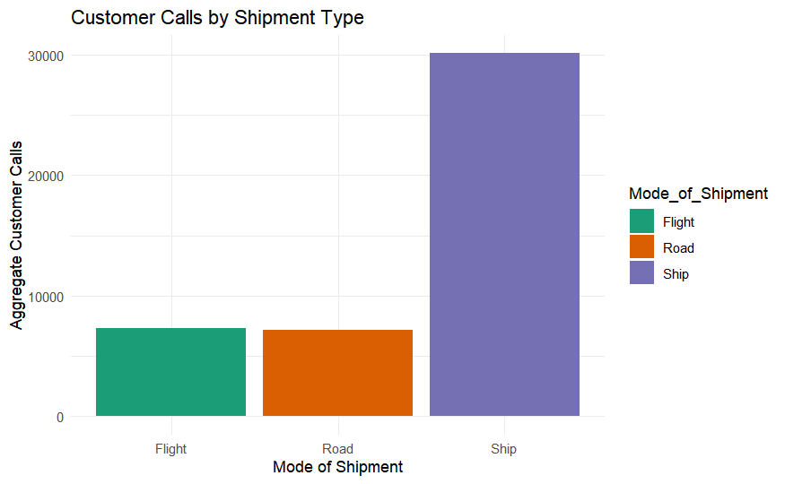

```r
#Aggregate customer care calls by mode of shipment
aggregated_data <- my_data[, .(Total_Customer_Calls = sum(Customer_care_calls)), by = Mode_of_Shipment]

ggplot(aggregated_data, aes(x = Mode_of_Shipment, y = Total_Customer_Calls, fill = Mode_of_Shipment)) +
  geom_bar(stat = "identity") +
  scale_fill_brewer(palette="Dark2")+
  labs(title = "Customer Calls by Shipment Type",
       x = "Mode of Shipment",
       y = "Aggregate Customer Calls") +
  theme_minimal()
```

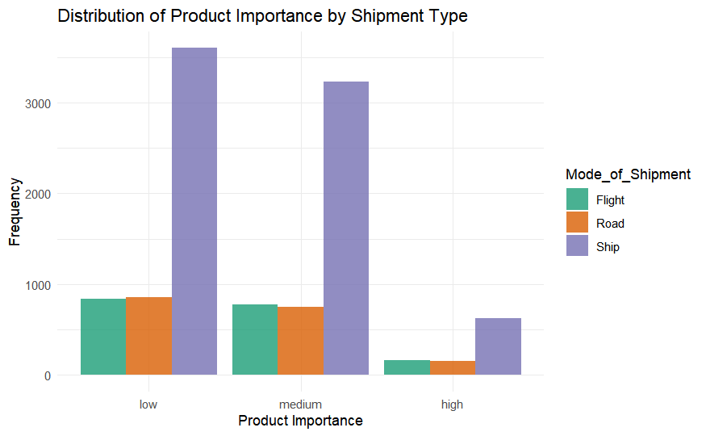

```r
#Product Importance
ggplot(my_data, aes(x = Product_importance, fill = Mode_of_Shipment)) +
  geom_bar(position = "dodge", alpha = 0.8) +
   scale_fill_brewer(palette="Dark2") +
  labs(title = "Distribution of Product Importance by Shipment Type",
       x = "Product Importance",
       y = "Frequency") +
  theme_minimal()
```

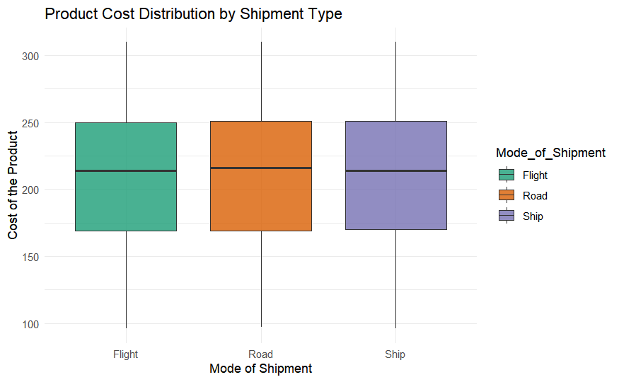

```r
#Boxplot for product costs by shipment type
ggplot(my_data, aes(x = Mode_of_Shipment, y = Cost_of_the_Product, fill = Mode_of_Shipment)) +
  geom_boxplot(alpha = 0.8) +
  scale_fill_brewer(palette="Dark2")+
  labs(title = "Product Cost Distribution by Shipment Type",
       x = "Mode of Shipment",
       y = "Cost of the Product") +
  theme_minimal()
```

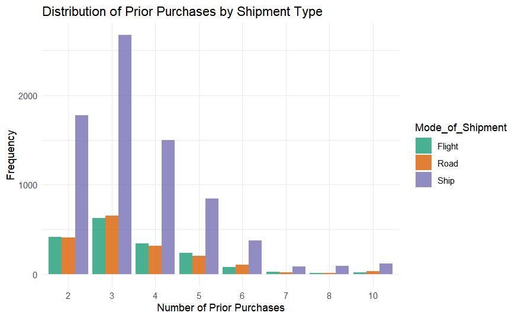

```r
#Prior purchases relationship
ggplot(my_data, aes(x = factor(Prior_purchases), fill = Mode_of_Shipment)) +
  geom_bar(position = "dodge", alpha = 0.8) +
  scale_fill_brewer(palette = "Dark2") +
  labs(title = "Distribution of Prior Purchases by Shipment Type",
       x = "Number of Prior Purchases",
       y = "Frequency") +
  theme_minimal()
```

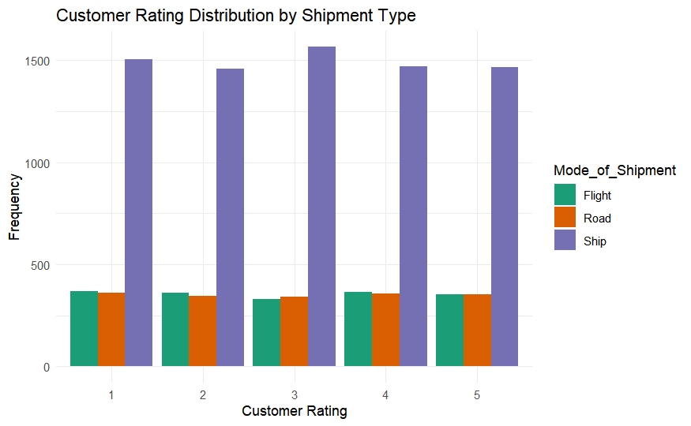

```r
#Customer rating distribution
ggplot(my_data, aes(x = factor(Customer_rating), fill = Mode_of_Shipment)) +
  geom_bar(position = "dodge", stat = "count") +
  labs(title = "Customer Rating Distribution by Shipment Type",
       x = "Customer Rating",
       y = "Frequency") +
   scale_fill_brewer(palette="Dark2")+
  theme_minimal()
```

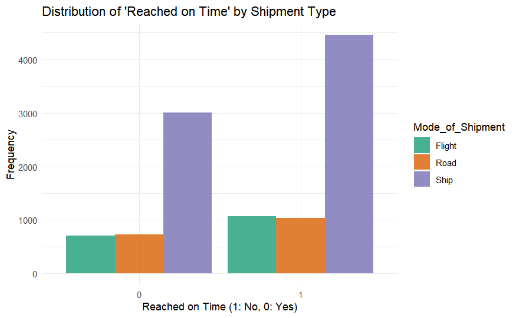

```r
#Reached on time vs Shipment type
ggplot(my_data, aes(x = factor(Reached_on_Time), fill = Mode_of_Shipment)) +
  geom_bar(position = "dodge", alpha = 0.8) +
  scale_fill_brewer(palette = "Dark2") +
  labs(title = "Distribution of 'Reached on Time' by Shipment Type",
       x = "Reached on Time (1: No, 0: Yes)",
       y = "Frequency") +
  theme_minimal()
```

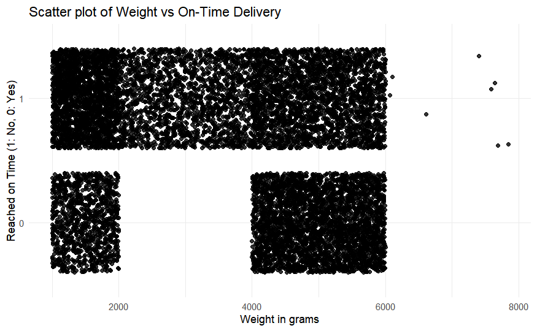

```r
#Relationship between Reached on time and Weight of product
ggplot(my_data, aes(x = Weight_in_gms, y = factor(Reached_on_Time))) +
  geom_jitter(alpha = 0.8) +
  labs(title = "Scatter plot of Weight vs On-Time Delivery",
       x = "Weight in grams",
       y = "Reached on Time (1: No, 0: Yes)",
       color = "Mode of Shipment") +
  theme_minimal()
```

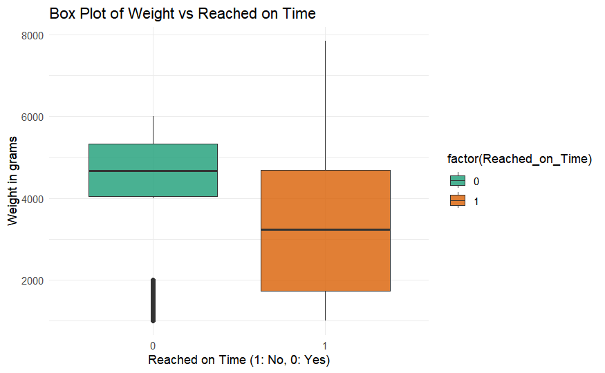

```r
#Relationship between Weight and Reached on time
ggplot(my_data, aes(x = factor(Reached_on_Time), y = Weight_in_gms, fill = factor(Reached_on_Time))) +
  geom_boxplot(alpha = 0.8) +
  scale_fill_brewer(palette = "Dark2") +
  labs(title = "Box Plot of Weight vs Reached on Time",
       x = "Reached on Time (1: No, 0: Yes)",
       y = "Weight in grams") +
  theme_minimal()
```

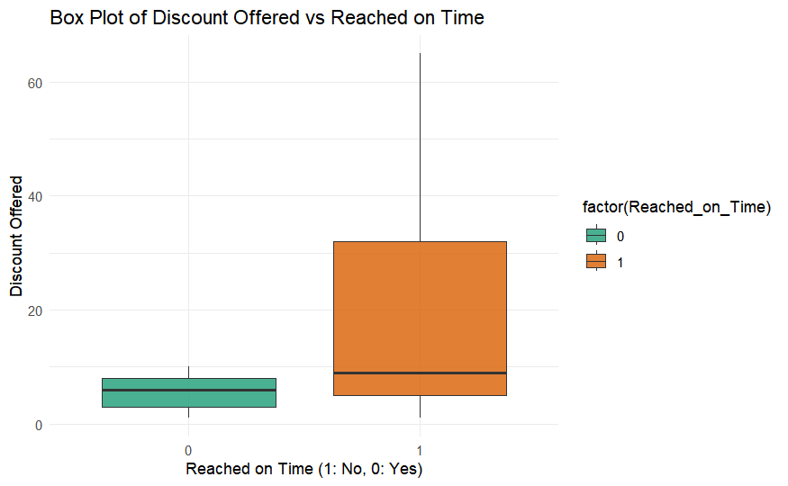

```r
#Relationship between Discount offered and Reached on time
ggplot(my_data, aes(x = factor(Reached_on_Time), y = Discount_offered, fill = factor(Reached_on_Time))) +
  geom_boxplot(alpha = 0.8) +
  scale_fill_brewer(palette = "Dark2") +
  labs(title = "Box Plot of Discount Offered vs Reached on Time",
       x = "Reached on Time (1: No, 0: Yes)",
       y = "Discount Offered") +
  theme_minimal()
```

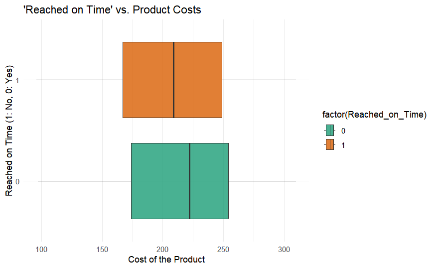

```r
#Relationship between Reached on time and Product costs
ggplot(my_data, aes(x = Cost_of_the_Product, y = factor(Reached_on_Time), fill = factor(Reached_on_Time))) +
  geom_boxplot(alpha = 0.8) +
  scale_fill_brewer(palette = "Dark2") +
  labs(title = "'Reached on Time' vs. Product Costs",
       x = "Cost of the Product",
       y = "Reached on Time (1: No, 0: Yes)") +
  theme_minimal()
```

# Logistic Regression

I started with the Logistic Regression model by using the R base function *glm*.

Exploring the predicted class probabilities *p2* under *fitted values*, I applied a decision rule by putting a condition where all the class probabilities greater than 0.5 would receive a 1 binary value. Otherwise, a 0 will be assigned. The accuracy of the model (*the share of correct class predictions*) is 64 %

```r
#Estimate the logistic model
model_logit <-glm(Reached_on_Time ~ Mode_of_Shipment + Customer_care_calls + Customer_rating + Cost_of_the_Product + Prior_purchases + Product_importance + Gender + Discount_offered + Weight_in_gms, data=my_data, family = "binomial")

#*Beta* vectors
coef(model_logit)
```

```
         (Intercept) Mode_of_ShipmentRoad Mode_of_ShipmentShip  Customer_care_calls      Customer_rating
        1.4431991226        -0.0346040577        -0.0201143313        -0.1073145539         0.0250037136
 Cost_of_the_Product      Prior_purchases Product_importance.L Product_importance.Q              GenderM
       -0.0019684913        -0.0769605712         0.2423882200         0.1314445468         0.0512327807
    Discount_offered        Weight_in_gms
        0.1118256503        -0.0002394368
```

```r
#Class Probabilities
head(model_logit$fitted.values)
```

```
        1         2         3         4         5         6
0.9932539 0.9982592 0.9939629 0.7895671 0.9941029 0.8163458
```

```r
#Decision rule
my_data[, k_pred := ifelse(model_logit$fitted.values > 0.5, 1, 0)]
head(my_data$k_pred)
```

```
[1] 1 1 1 1 1 1
```

```r
#Accuracy of the model
mean(my_data$k_pred == my_data$Reached_on_Time)
```

```
[1] 0.6395127
```

# Decision Trees

I initiated my analysis by constructing a decision tree using the *rpart* function. The resulting tree structure was visualized using the *prp* function.

Subsequently, I aimed to simplify the tree model through pruning.

I evaluated the accuracy of the decision tree by comparing its predictions to the actual values of `Reached_on_Time` where I got a 68.4 % accuracy.

To further optimize the decision tree model, I conducted an exploration of hyperparameters. I put different values for the minimum observations *min_obs*, maximum depth *max_depth*, and complexity parameter *cp_val* and ran a grid search. The grid search explored different combinations of the hyperparameters to find the set that would maximize the accuracy. For each combination of hyperparameters, I built decision tree models, calculated their accuracy, and stored the results in a structured format. The results were visualized in a 3D scatter plot, where the color scale indicated the model accuracy across different parameter settings. This visualization identified a parameter region with better model performance. From the hyperparameter exploration, I selected the combination of hyperparameters that yielded the highest accuracy. This optimal parameter set was then used to construct a final decision tree model (model_tree_3). The mean accuracy of this model’s predictions was calculated and found to be 70 %

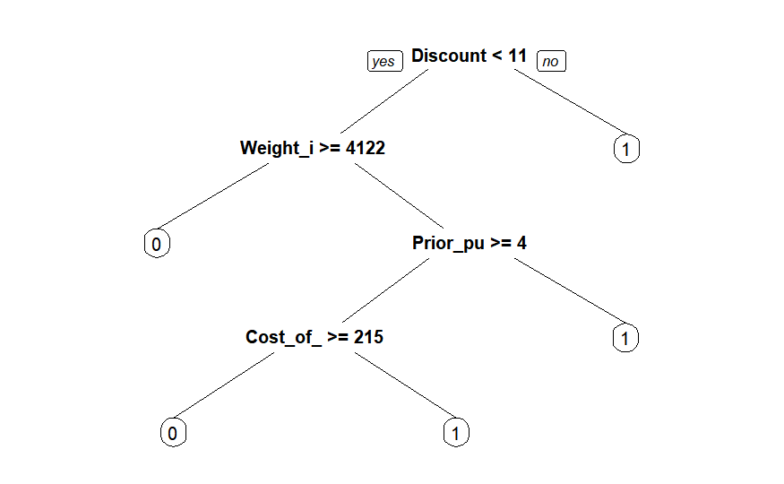

```r
# Model the tree
model_tree <- rpart(data=my_data, formula = Reached_on_Time ~ Mode_of_Shipment + Customer_care_calls + Customer_rating + Cost_of_the_Product + Prior_purchases + Product_importance + Discount_offered + Weight_in_gms, method="class")
prp(model_tree)
```

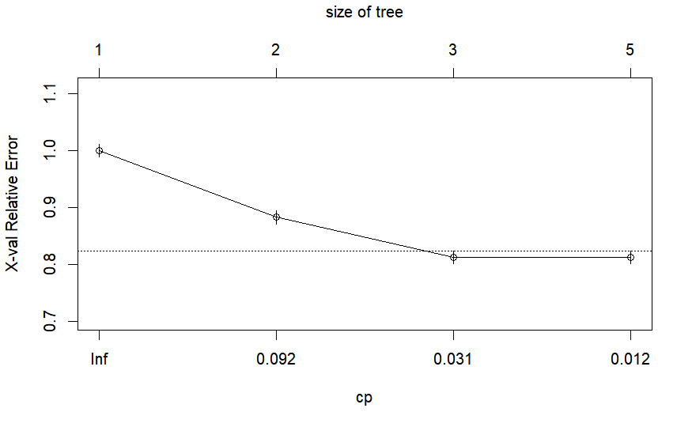

```r
plotcp(model_tree)
```

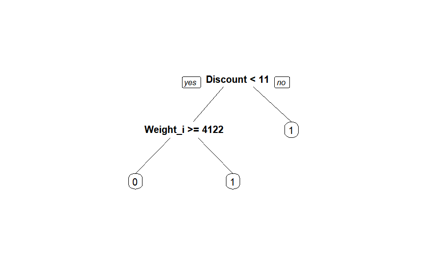

```r
# Determine the minimum complexity parameter (cp) for pruning
min_cp <- model_tree$cptable[which.min(model_tree$cptable[, "xerror"]), "CP"]
# Prune the decision tree model using the minimum cp
model_tree_2 <- prune(model_tree, cp = min_cp )
# Plot the pruned decision tree model
prp(model_tree_2)
```

```r
mean(predict(model_tree, my_data, type = "class")==my_data$Reached_on_Time)
```

```
[1] 0.6841531
```

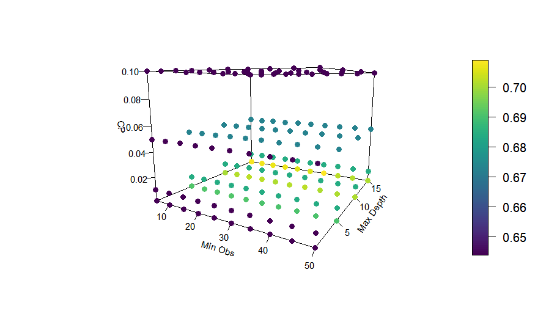

```r
## Investigating hyperparameters
# Define the values for minimum observations, maximum depth, and complexity parameter (cp)
min_obs <- seq(from = 5, to = 50, by = 5)
max_depth <- c(1, 5, 10, 15)
cp_val <- c(0.001, 0.01, 0.05, 0.1)

# Create an empty data frame to store the results
results <- data.frame()

# Iterate over the combinations of min_obs, max_depth, and cp_value
for (i in 1:length(min_obs)) {
  for (j in 1:length(max_depth)) {
    for (k in 1:length(cp_val)) {
      # Build a decision tree model with the specified parameters
      model <- rpart(data = my_data, formula = Reached_on_Time ~ Mode_of_Shipment + Customer_care_calls + Customer_rating + Cost_of_the_Product + Prior_purchases + Product_importance + Discount_offered + Weight_in_gms,
                     method = "class",
                     cp = cp_val[k],
                     maxdepth = max_depth[j],
                     minbucket = min_obs[i])

      # Calculate the accuracy of the model predictions
      acc <- mean(predict(model, my_data, type = "class") == my_data$Reached_on_Time)

      # Store the accuracy and parameter values to the results data frame
      results <- rbind(results, c(acc, min_obs[i], max_depth[j], cp_val[k]))
    }
  }
}

# Set column names for the results data frame
colnames(results) <- c("accuracy", "min_obs", "max_depth", "cp")

# Create a 3D scatter plot using scatter3D
plot3D::scatter3D(x = results$min_obs, y = results$max_depth, z = results$cp,
                  theta = 30, phi = 10,
                  xlab = "Min Obs", ylab = "Max Depth", zlab = "CP",
                  ticktype = "detailed",
                  pch = 19,
                  cex.axis = 0.75, cex.lab = 0.75, expand = 0.75,
                  colvar = results$accuracy, col = viridis(100))
```

```r
# Select the optimal parameter combination with the highest accuracy and store them
opt_params <- results[which.max(results$accuracy),]

# Build a decision tree model using the optimal parameters
model_tree_3 <- rpart(data=my_data, formula = Reached_on_Time ~ Mode_of_Shipment + Customer_care_calls + Customer_rating + Cost_of_the_Product + Prior_purchases + Product_importance + Discount_offered + Weight_in_gms,
                      method = "class",
                      cp = opt_params$cp,
                      maxdepth = opt_params$max_depth,
                      minbucket = opt_params$min_obs)

# Calculate the mean accuracy of the model predictions
mean(predict(model_tree_3, my_data, type = "class") == my_data$Reached_on_Time)
```

```
[1] 0.7089735
```

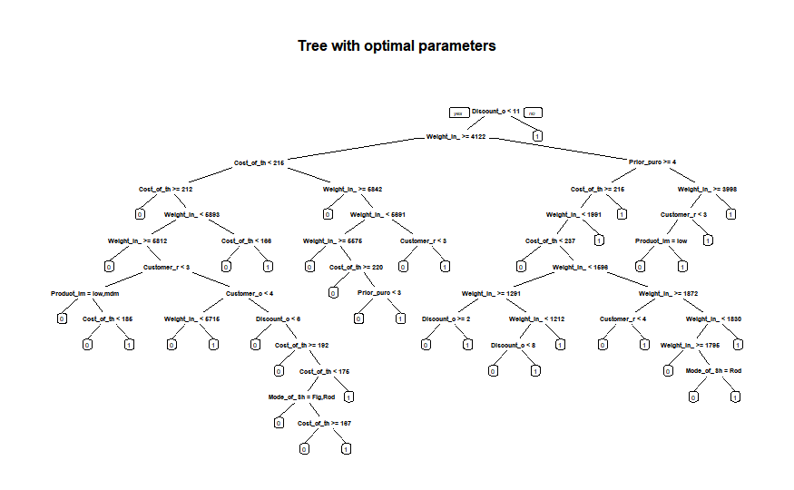

```r
# Plot the optimal decision tree
prp(model_tree_3, main = "Tree with optimal parameters")
```

# Model Evaluation

Now, I built a confusion matrix to check how many observations I got correct and how many wrong. Firstly, I used the model of logistic regression as I explained earlier and the decision rules where the predicted probability of not reaching on time was greater than 0.5, the product was classified as not reaching on time ; otherwise, it was classified as reaching on time. Then, I created another confusion matrix. This time I evaluated the optimized decision tree.

We can see that the decision tree model did much better in terms of sensitivity with an accuracy of 83 % . This kind of model has predicted `Product reaches on time` pretty well. On the other side the logistic regression predicted the true negative values ( Specificity -> `to not reach on time`) a bit better. The accuracy was 68 % . We could tell, so far, that the tree has done a much better prediction in comparison with logistic regression.

After that, I wanted to increase the accuracy of the logistic regression. I looped through all thresholds from 0.01 to 0.99 and found the accuracy for each data point for each different threshold. After that, I stored the results in the data frame and plotted a graph that showed the relationship between thresholds and accuracy. I noticed that I could do better for the logistic regression by increasing the threshold a bit more. Lastly, I built another logistic regression. This time with the new threshold which would increase the accuracy that the graph showed. At the end the accuracy that I got was 65.5 %

Overall, if we compare the 2 models implemented in my project, we could tell that the tree model made a better prediction, with an accuracy of 70.9 % in comparison with the logistic regression where we got a 65.5 % accuracy at the end.

```r
#Confusion matrix for logistic regression
confusionMatrix(data = as.factor(my_data$k_pred),
                reference = as.factor(my_data$Reached_on_Time))
```

```
Confusion Matrix and Statistics

          Reference
Prediction    0    1
         0 2561 2090
         1 1875 4473

               Accuracy : 0.6395
                 95% CI : (0.6305, 0.6485)
    No Information Rate : 0.5967
    P-Value [Acc > NIR] : < 2.2e-16

                  Kappa : 0.2569

 Mcnemar's Test P-Value : 0.0006775

            Sensitivity : 0.5773
            Specificity : 0.6815
         Pos Pred Value : 0.5506
         Neg Pred Value : 0.7046
             Prevalence : 0.4033
         Detection Rate : 0.2328
   Detection Prevalence : 0.4229
      Balanced Accuracy : 0.6294

       'Positive' Class : 0
```

```r
#Confusion matrix for model_tree_3
tree_predictions <- predict(model_tree_3, my_data, type = "class")


confusionMatrix(data = as.factor(tree_predictions),
                                         reference = as.factor(my_data$Reached_on_Time))
```

```
Confusion Matrix and Statistics

          Reference
Prediction    0    1
         0 3691 2456
         1  745 4107

               Accuracy : 0.709
                 95% CI : (0.7004, 0.7175)
    No Information Rate : 0.5967
    P-Value [Acc > NIR] : < 2.2e-16

                  Kappa : 0.4309

 Mcnemar's Test P-Value : < 2.2e-16

            Sensitivity : 0.8321
            Specificity : 0.6258
         Pos Pred Value : 0.6005
         Neg Pred Value : 0.8465
             Prevalence : 0.4033
         Detection Rate : 0.3356
   Detection Prevalence : 0.5589
      Balanced Accuracy : 0.7289

       'Positive' Class : 0
```

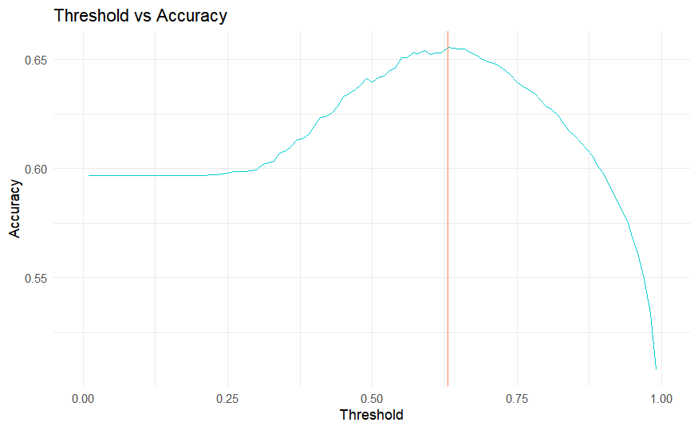

```r
#Increasing the accuracy of logistic regression
thresholds <- seq(0.01, 0.99, by = 0.01)


threshold_results <- data.frame(Threshold = thresholds, Accuracy = numeric(length(thresholds)))

#Loop
for (i in seq_along(thresholds)) {
  predictions <- ifelse(model_logit$fitted.values > thresholds[i], 1, 0)
  accuracy <- mean(predictions == my_data$Reached_on_Time)
  threshold_results$Accuracy[i] <- accuracy
}

#Storing the threshold that maximizes accuracy
optimal_threshold <- threshold_results$Threshold[which.max(threshold_results$Accuracy)]


#Thresholds vs accuracy plot
ggplot(threshold_results, aes(x = Threshold, y = Accuracy)) +
  geom_line(color = "cyan3") +
  labs(x = "Threshold", y = "Accuracy", title = "Threshold vs Accuracy") +
  geom_vline(xintercept = optimal_threshold, color = "coral") +
  xlim(0, 1)+
  theme_minimal()
```

```r
#New logistic regression with new threshold
model_logit_2 <-glm(Reached_on_Time ~ Mode_of_Shipment + Customer_care_calls + Customer_rating + Cost_of_the_Product + Prior_purchases + Product_importance + Gender + Discount_offered + Weight_in_gms, data=my_data, family = "binomial")

coef(model_logit_2)
```

```
         (Intercept) Mode_of_ShipmentRoad Mode_of_ShipmentShip  Customer_care_calls      Customer_rating
        1.4431991226        -0.0346040577        -0.0201143313        -0.1073145539         0.0250037136
 Cost_of_the_Product      Prior_purchases Product_importance.L Product_importance.Q              GenderM
       -0.0019684913        -0.0769605712         0.2423882200         0.1314445468         0.0512327807
    Discount_offered        Weight_in_gms
        0.1118256503        -0.0002394368
```

```r
head(model_logit_2$fitted.values)
```

```
        1         2         3         4         5         6
0.9932539 0.9982592 0.9939629 0.7895671 0.9941029 0.8163458
```

```r
my_data[, k_pred_2 := ifelse(model_logit_2$fitted.values > optimal_threshold, 1, 0)]
head(my_data$k_pred_2)
```

```
[1] 1 1 1 1 1 1
```

```r
#Accuracy of the new logistic model
mean(my_data$k_pred_2 == my_data$Reached_on_Time)
```

```
[1] 0.6554232
```

# Feature Engineering

At this part I wanted to apply Feature Engineering to my dataset. Firstly, I built a correlation matrix to show the correlation between the numeric variables. I distinguished a positive relationship of 0.32 for the `Cost of the product` and `Customer care calls`. In this case, I expect that as the price of the product increases, customers may require more customer assistance because they care more for their product. I found reasonable to create a new variable by multiplying these 2 variables and add a new column named `Calls_cost`. This new variable would capture the interaction between `Cost of the product` and `Customer care calls`. This means that the impact on my target variable would not be influenced only by the costs and number of customer care calls alone but also by their combined effect. After I created the new variable, I run the logistic model. This time I also included the new variable. By checking at the coefficients I noticed that the effect of `Calls cost` with the target variable was negative. This means that, an increase in this variable would decrease the probability of *not reaching on time* . At the end, the model was improved but not with a high increase.

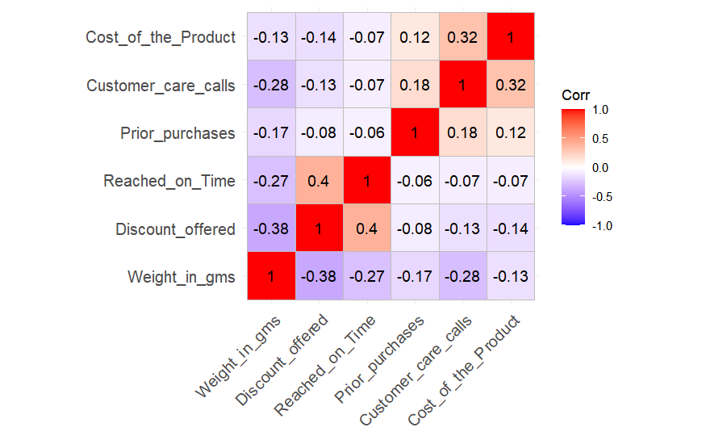

```r
ggcorrplot(corr = cor(my_data[, .(Customer_care_calls, Cost_of_the_Product, Prior_purchases, Discount_offered, Weight_in_gms, Reached_on_Time)]),
           hc.order = TRUE,
           lab = TRUE)
```

```r
my_data [, Calls_Cost := Customer_care_calls*Cost_of_the_Product ]

model_logit_3 <-glm(Reached_on_Time ~ Mode_of_Shipment + Customer_care_calls + Customer_rating + Cost_of_the_Product + Prior_purchases + Product_importance + Gender + Discount_offered + Weight_in_gms + Calls_Cost, data=my_data, family = "binomial")

coef(model_logit_3)
```

```
         (Intercept) Mode_of_ShipmentRoad Mode_of_ShipmentShip  Customer_care_calls      Customer_rating
        0.0554700962        -0.0361816490        -0.0201823559         0.2608909036         0.0253842036
 Cost_of_the_Product      Prior_purchases Product_importance.L Product_importance.Q              GenderM
        0.0048818848        -0.0796566809         0.2405494035         0.1303265535         0.0489469784
    Discount_offered        Weight_in_gms           Calls_Cost
        0.1104873321        -0.0002598072        -0.0016608458
```

```r
head(model_logit_3$fitted.values)
```

```
        1         2         3         4         5         6
0.9934600 0.9982294 0.9929927 0.7891101 0.9933520 0.8114625
```

```r
my_data[, k_pred_3 := ifelse(model_logit_3$fitted.values > optimal_threshold, 1, 0)]
head(my_data$k_pred_3)
```

```
[1] 1 1 1 1 1 1
```

```r
mean(my_data$k_pred_3 == my_data$Reached_on_Time)
```

```
[1] 0.6560596
```